# Install Git in Windows

## Download Git

- Go to the following website and click on the Windows download link:

http://git-scm.com/downloads

[figure not shown]

## Install Git

- Once the file is done downloading, open it up to begin the Git installation

[figure not shown]

## Install Git

[figure not shown]

## Open Git Bash

- Find a program called Git Bash, which is the command line environment for interacting with Git
- It should be located in the Git directory within your Start Menu (or in the directory into which Git was installed)

[figure not shown]

## Open Git Bash

- Once Git Bash opens, you'll see a short welcome message followed by the name of your computer and a dollar sign on the next line
- The dollar sign means that it's your turn to type a command

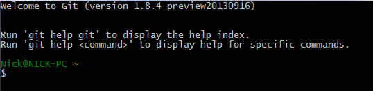

## Configure Username and Email

- Each commit to a Git repository will be "tagged" with the username of the person who made the commit
- Enter the following commands in Git Bash, one at a time, to set your username and email:

```
$ git config --global user.name "Your Name Here"
$ git config --global user.email "your_email@example.com"
```

- Make sure there are 2 dashes side-by-side before the word "global"
- You'll only have to do this once, but you can always change these down the road using the same commands

## Configure Username and Email

- Now type the following to confirm your changes (they may be listed toward the bottom):

```
$ git config --list
```

- Make sure there are 2 separate dashes (side-by-side) before the word "global"

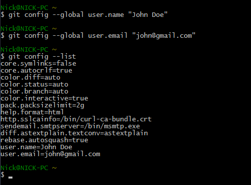

## What's Next?

- Go ahead and close Git Bash with the following command:

```
$ exit
```

- Now that Git is set up on your computer, we're ready to move on to GitHub, which is a web-based platform that lets you do some pretty cool stuff
- Once GitHub is up and running, we'll show you how to start using these tools to your benefit